# 06 · Progress Evaluation 2 showcase (Stages 6-8)

**SkillPath** · IT3051 Fundamentals of Data Mining · group KND_12 · SLIIT Kandy Uni

One notebook to walk the evaluator through everything since Evaluation 1, top to bottom. It reads the results written by the scripts (so no 40-minute rerun is needed in the lab), and recomputes the key numbers live from the saved model where that takes seconds.

| Part | What it shows | Assignment item |
| --- | --- | --- |
| **A** | The processed data, opened and explained (requested at Evaluation 1) | Stage 4 follow-up |
| **B** | Seven algorithms, why each, validation strategy, metrics, comparison, error analysis | Stage 6 |
| **C** | Imbalance handling, feature experiments, hyper-parameter search, tuned vs baseline | Stage 7 |
| **D** | The selection rule and the final model, with justification | Stage 7 |
| **E** | The one held-out test evaluation, reproduced live from `model.joblib` | Stage 7 |
| **F** | Live prediction for a sample user, and which skills drive a prediction | bridge to Stages 9-10 |

**Run it:** on Google Colab or locally, `Runtime/Kernel → Restart & Run All`. Everything runs in under a minute (plus about 90 s the first time, to write the full feature-matrix Excel file); the raw survey CSV is not needed.

### Setup (only does anything on Google Colab)

On Colab this cell downloads the project from GitHub and installs the exact scikit-learn version the model was saved with (about 1 minute). On a laptop with the project's virtual environment it does nothing.

The repository is private, so Colab needs a read-only GitHub token: click the **key icon** in Colab's left sidebar, add a secret named `GITHUB_TOKEN`, and switch on notebook access.

```python
import os
import subprocess
import sys

IN_COLAB = "google.colab" in sys.modules
REPO = "PasinduSuraweera/skillpath"
BRANCH = "feature/evaluation2-showcase"

if IN_COLAB:
    repo_dir = "/content/skillpath"
    if not os.path.isdir(repo_dir):
        try:
            from google.colab import userdata
            token = userdata.get("GITHUB_TOKEN")
            url = f"https://{token}@github.com/{REPO}.git"
        except Exception:
            url = f"https://github.com/{REPO}.git"   # works only if the repo is public
        clone = subprocess.run(["git", "clone", "-q", "--depth", "1", "-b", BRANCH, url, repo_dir],
                               capture_output=True, text=True)
        if clone.returncode != 0:   # message kept generic so the token is never printed
            raise RuntimeError("Could not download the repository. Check the GITHUB_TOKEN secret "
                               "exists, has notebook access switched on, and can read the repo.")
    subprocess.run([sys.executable, "-m", "pip", "install", "-q",
                    "scikit-learn==1.8.0", "xlsxwriter", "pyarrow"], check=True)
    sys.path.insert(0, f"{repo_dir}/src")
    os.chdir(f"{repo_dir}/notebooks")
    print("Colab setup done:", repo_dir)
else:
    print("Running locally, no setup needed.")
```

```
Running locally, no setup needed.
```

```python
import json
from pathlib import Path

import joblib
import matplotlib.pyplot as plt
import numpy as np
import pandas as pd
from IPython.display import Markdown, display

from skillpath import config as C
from skillpath import modelling as M
from skillpath import targets, viz
from skillpath.profile import profile_to_frame

viz.setup()
pd.set_option("display.width", 220, "display.max_columns", 60, "display.max_colwidth", 60)


def label(role):
    return C.JOB_ROLE_LABEL.get(role, role)


def read_csv(name):
    return pd.read_csv(C.REPORTS_DIR / name)


def read_json(name):
    return json.loads((C.REPORTS_DIR / name).read_text())
```

# Part A · The processed data

At Evaluation 1 the processed data could not be shown because it is stored as Parquet, which does not open in Excel or a text editor. **Parquet was a deliberate choice** (it keeps column types, so numbers stay numbers and missing values stay missing, and it is about 5× smaller than CSV), but it needs code to open. This part opens every file and, at the end, exports an Excel copy that can be opened on any laptop.

## A1 · What is in `data/processed/`

```python
files = {
    "train.parquet": "Cleaned training respondents (one row per person, survey format)",
    "test.parquet": "Cleaned held-out respondents, same columns, never used for any decision",
    "features_core_train.parquet": "train after the Stage 4 pipeline: the 479 numbers the model sees",
    "features_core_test.parquet": "test after the same fitted pipeline",
    "role_cohort.parquet": "train + test together, used for the app's role statistics",
    "split_ids.csv": "ResponseId → train/test, freezes the 80/20 split",
}
rows = []
for name, what in files.items():
    p = C.PROCESSED_DIR / name
    df = pd.read_csv(p) if p.suffix == ".csv" else pd.read_parquet(p)
    rows.append({"file": name, "rows": len(df), "columns": df.shape[1],
                 "size_MB": round(p.stat().st_size / 1e6, 2), "what it is": what})
pd.DataFrame(rows)
```

|  | file | rows | columns | size_MB | what it is |
| --- | --- | --- | --- | --- | --- |
| 0 | train.parquet | 18457 | 53 | 2.07 | Cleaned training respondents (one row per person, survey... |
| 1 | test.parquet | 4615 | 53 | 0.63 | Cleaned held-out respondents, same columns, never used f... |
| 2 | features_core_train.parquet | 18457 | 482 | 1.57 | train after the Stage 4 pipeline: the 479 numbers the mo... |
| 3 | features_core_test.parquet | 4615 | 482 | 0.67 | test after the same fitted pipeline |
| 4 | role_cohort.parquet | 23072 | 53 | 2.53 | train + test together, used for the app's role statistics |
| 5 | split_ids.csv | 23072 | 2 | 0.27 | ResponseId → train/test, freezes the 80/20 split |

## A2 · The cleaned rows (`train.parquet`)

Each row is one developer. Multi-select survey answers keep the survey's own `;` separator here; they are turned into 0/1 columns only inside the pipeline, so the same pipeline can be applied to a single profile from the web form.

```python
train = pd.read_parquet(C.PROCESSED_DIR / "train.parquet")
test = pd.read_parquet(C.PROCESSED_DIR / "test.parquet")
X_train, y_train = M.load_train()
model_cols = list(X_train.columns)

print(f"train: {train.shape[0]:,} respondents × {train.shape[1]} columns")
print(f"test : {test.shape[0]:,} respondents × {test.shape[1]} columns")
print(f"columns fed to the model: {len(model_cols)}  (the rest are IDs, the target, and app-only fields)")
train[["ResponseId", C.TARGET_JOB, "RoleFamily"] + model_cols[:8]].head(8)
```

```
train: 18,457 respondents × 53 columns
test : 4,615 respondents × 53 columns
columns fed to the model: 29  (the rest are IDs, the target, and app-only fields)
```

|  | ResponseId | JobRole | RoleFamily | LanguageHaveWorkedWith | LanguageWantToWorkWith | LanguageChoice | DatabaseHaveWorkedWith | DatabaseWantToWorkWith | DatabaseChoice | PlatformHaveWorkedWith | PlatformWantToWorkWith |
| --- | --- | --- | --- | --- | --- | --- | --- | --- | --- | --- | --- |
| 0 | 2 | Developer, back-end | Backend | Java | Java;Python;Swift | Yes | Dynamodb;MongoDB | Dynamodb;MongoDB | Yes | Amazon Web Services (AWS);Datadog;Docker;Homebrew;Kubern... | Amazon Web Services (AWS);Datadog;Docker;Homebrew;Kubern... |
| 1 | 4 | Developer, back-end | Backend | Java;Kotlin;SQL | Java;Kotlin | Yes | NaN | NaN | No | Amazon Web Services (AWS);Google Cloud | Amazon Web Services (AWS);Google Cloud |
| 2 | 7 | Developer, full-stack | Full-stack | JavaScript;TypeScript | JavaScript;TypeScript | Yes | NaN | NaN | No | Amazon Web Services (AWS);Docker;Homebrew;npm;pnpm;Webpack | NaN |
| 3 | 9 | Data engineer | Data Eng | Java;Python;Scala | Scala | NaN | Cassandra;Databricks SQL;DuckDB;Dynamodb;MariaDB;Microso... | Dynamodb;MySQL;PostgreSQL | NaN | Amazon Web Services (AWS);Datadog;Docker;Microsoft Azure... | Amazon Web Services (AWS);Datadog;Microsoft Azure |
| 4 | 11 | Developer, back-end | Backend | HTML/CSS;Java;JavaScript;SQL;TypeScript | HTML/CSS;Java;JavaScript;SQL;TypeScript | Yes | H2;Microsoft SQL Server;PostgreSQL;Redis | H2;Microsoft SQL Server;PostgreSQL;Redis | Yes | Kubernetes;Maven (build tool);npm | Kubernetes;Maven (build tool);npm |
| 5 | 12 | Developer, back-end | Backend | C# | C# | Yes | Microsoft SQL Server;SQLite | Microsoft SQL Server;PostgreSQL | Yes | NaN | NaN |
| 6 | 13 | Developer, front-end | Frontend | HTML/CSS;JavaScript;TypeScript | C#;TypeScript | NaN | NaN | NaN | No | NaN | NaN |
| 7 | 18 | Developer, full-stack | Full-stack | HTML/CSS;JavaScript;Python;SQL | Python | Yes | MariaDB;MongoDB;MySQL;SQLite | MongoDB | Yes | NaN | NaN |

```python
summary = pd.DataFrame({
    "dtype": train[model_cols].dtypes.astype(str),
    "non_missing": train[model_cols].notna().sum(),
    "missing_%": (train[model_cols].isna().mean() * 100).round(1),
    "example": train[model_cols].apply(lambda s: s.dropna().iloc[0] if s.notna().any() else None),
})
summary["example"] = summary["example"].astype(str).str.slice(0, 55)
summary
```

|  | dtype | non_missing | missing_% | example |
| --- | --- | --- | --- | --- |
| LanguageHaveWorkedWith | str | 18457 | 0.0 | Java |
| LanguageWantToWorkWith | str | 15774 | 14.5 | Java;Python;Swift |
| LanguageChoice | str | 18107 | 1.9 | Yes |
| DatabaseHaveWorkedWith | str | 15218 | 17.5 | Dynamodb;MongoDB |
| DatabaseWantToWorkWith | str | 11787 | 36.1 | Dynamodb;MongoDB |
| DatabaseChoice | str | 18067 | 2.1 | Yes |
| PlatformHaveWorkedWith | str | 14417 | 21.9 | Amazon Web Services (AWS);Datadog;Docker;Homebrew;Kuber |
| PlatformWantToWorkWith | str | 11559 | 37.4 | Amazon Web Services (AWS);Datadog;Docker;Homebrew;Kuber |
| PlatformChoice | str | 17806 | 3.5 | Yes |
| WebframeHaveWorkedWith | str | 13693 | 25.8 | Spring Boot |
| WebframeWantToWorkWith | str | 10578 | 42.7 | Spring Boot |
| WebframeChoice | str | 17804 | 3.5 | Yes |
| DevEnvsHaveWorkedWith | str | 15166 | 17.8 | IntelliJ IDEA;PyCharm;Visual Studio Code;Xcode |
| DevEnvsWantToWorkWith | str | 11997 | 35.0 | IntelliJ IDEA;PyCharm;Visual Studio Code;Xcode |
| DevEnvsChoice | str | 17689 | 4.2 | Yes |
| AIModelsHaveWorkedWith | str | 9403 | 49.1 | openAI GPT (chatbot models) |
| AIModelsWantToWorkWith | str | 6837 | 63.0 | openAI GPT (chatbot models) |
| AIModelsChoice | str | 17209 | 6.8 | Yes |
| SOTagsHaveWorkedWith | str | 10224 | 44.6 | Amazon Bedrock |
| SOTagsWantToWorkWith | str | 7734 | 58.1 | RAG |
| YearsCode | float64 | 18289 | 0.9 | 10.0 |
| WorkExp | float64 | 18366 | 0.5 | 2.0 |
| EdLevel | str | 18429 | 0.2 | Associate degree (A.A., A.S., etc.) |
| AISelect | str | 18014 | 2.4 | Yes, I use AI tools weekly |
| AIAgents | str | 17531 | 5.0 | No, and I don't plan to |
| AIAcc | str | 17902 | 3.0 | Neither trust nor distrust |
| AISent | str | 17967 | 2.7 | Indifferent |
| Country | str | 18457 | 0.0 | Netherlands |
| LearnCodeAI | str | 18420 | 0.2 | Yes, I learned how to use AI-enabled tools for my perso |

Missing values are **left missing on purpose** at this stage. The pipeline decides what a blank means per column: for a technology block, "skipped the question" becomes an `unknown` flag while "ticked I don't use any" is a genuine zero; numeric experience is median-imputed *inside each training fold* so no validation row influences the median.

## A3 · The split is clean and stratified

```python
overlap = set(train["ResponseId"]) & set(test["ResponseId"])
print(f"Respondents in both train and test: {len(overlap)}")
print(f"Test share: {len(test) / (len(train) + len(test)):.1%}")

dist = pd.DataFrame({
    "train_%": train[C.TARGET_JOB].value_counts(normalize=True) * 100,
    "test_%": test[C.TARGET_JOB].value_counts(normalize=True) * 100,
    "train_n": train[C.TARGET_JOB].value_counts(),
}).sort_values("train_n", ascending=False)
dist.index = dist.index.map(label)
dist["difference_pp"] = dist["train_%"] - dist["test_%"]
dist.round(2)
```

```
Respondents in both train and test: 0
Test share: 20.0%
```

| JobRole | train_% | test_% | train_n | difference_pp |
| --- | --- | --- | --- | --- |
| Full-stack Developer | 39.44 | 39.44 | 7279 | 0.00 |
| Back-end Developer | 20.32 | 20.30 | 3750 | 0.01 |
| Desktop / Enterprise Developer | 6.43 | 6.44 | 1187 | -0.00 |
| Front-end Developer | 6.07 | 6.07 | 1120 | 0.00 |
| Embedded Developer | 4.18 | 4.18 | 771 | -0.00 |
| Mobile Developer | 4.00 | 4.01 | 739 | -0.00 |
| DevOps Engineer | 3.49 | 3.49 | 645 | 0.01 |
| Data Engineer | 2.44 | 2.45 | 451 | -0.01 |
| AI / ML Engineer | 1.89 | 1.89 | 349 | 0.01 |
| Data Scientist | 1.89 | 1.89 | 349 | 0.01 |
| System Administrator | 1.47 | 1.47 | 272 | 0.00 |
| Game / Graphics Developer | 1.42 | 1.43 | 262 | -0.01 |
| Cloud Infrastructure Engineer | 1.29 | 1.28 | 238 | 0.01 |
| Cybersecurity Specialist | 1.19 | 1.19 | 220 | 0.00 |
| QA / Test Engineer | 1.08 | 1.08 | 199 | -0.01 |
| Data / Business Analyst | 1.01 | 1.02 | 186 | -0.01 |
| Applied Scientist | 0.97 | 0.98 | 179 | -0.01 |
| AI Application Developer | 0.63 | 0.63 | 116 | 0.00 |
| Database Administrator / Engineer | 0.53 | 0.52 | 98 | 0.01 |
| UX / UI Designer | 0.25 | 0.26 | 47 | -0.01 |

Every role has the same share in train and test (differences are hundredths of a percentage point), which is what `stratify=JobRole` guarantees. The imbalance is visible too: Full-stack is about 39% of rows and UX/UI Designer is 47 rows, about 155:1.

## A4 · The transformed feature matrix (what the model actually sees)

```python
feat_train = pd.read_parquet(C.PROCESSED_DIR / "features_core_train.parquet")
fdict = read_csv("feature_dictionary.csv")
id_cols = ["ResponseId", C.TARGET_JOB, "RoleFamily"]
feature_cols = [c for c in feat_train.columns if c not in id_cols]
print(f"features_core_train: {feat_train.shape[0]:,} rows × {len(feature_cols)} features "
      f"(+ {', '.join(c for c in id_cols if c in feat_train.columns)} kept for traceability)")

groups = (fdict.assign(block=fdict["group"].str.replace(r" \((have|want)\)", "", regex=True))
          .groupby("block").size().sort_values(ascending=False).rename("features"))
display(groups.to_frame().T)
fdict.groupby("group").head(1)[["feature", "group", "type", "transformation"]].head(18)
```

```
features_core_train: 18,457 rows × 479 features (+ ResponseId, JobRole, RoleFamily kept for traceability)
```

| block | Platform | Language | Database | Webframe | DevEnvs | SOTags | AIModels | Region | Ordinal | Nominal | Experience |
| --- | --- | --- | --- | --- | --- | --- | --- | --- | --- | --- | --- |
| features | 89 | 88 | 65 | 61 | 59 | 45 | 37 | 13 | 10 | 6 | 6 |

|  | feature | group | type | transformation |
| --- | --- | --- | --- | --- |
| 0 | tech__Language_have__Ada | Language (have) | binary/numeric | 1 if 'Ada' selected |
| 43 | tech__Language_want__Ada | Language (want) | binary/numeric | 1 if 'Ada' selected |
| 87 | tech__Database_have__Amazon_Redshift | Database (have) | binary/numeric | 1 if 'Amazon_Redshift' selected |
| 119 | tech__Database_want__Amazon_Redshift | Database (want) | binary/numeric | 1 if 'Amazon_Redshift' selected |
| 151 | tech__Platform_have__APT | Platform (have) | binary/numeric | 1 if 'APT' selected |
| 195 | tech__Platform_want__APT | Platform (want) | binary/numeric | 1 if 'APT' selected |
| 239 | tech__Webframe_have__ASP.NET | Webframe (have) | binary/numeric | 1 if 'ASP.NET' selected |
| 269 | tech__Webframe_want__ASP.NET | Webframe (want) | binary/numeric | 1 if 'ASP.NET' selected |
| 299 | tech__DevEnvs_have__Aider | DevEnvs (have) | binary/numeric | 1 if 'Aider' selected |
| 328 | tech__DevEnvs_want__Aider | DevEnvs (want) | binary/numeric | 1 if 'Aider' selected |
| 357 | tech__AIModels_have__Alibaba_Cloud_Qwen_models | AIModels (have) | binary/numeric | 1 if 'Alibaba_Cloud_Qwen_models' selected |
| 375 | tech__AIModels_want__Alibaba_Cloud_Qwen_models | AIModels (want) | binary/numeric | 1 if 'Alibaba_Cloud_Qwen_models' selected |
| 393 | tech__SOTags_have__.NET_8_or_higher | SOTags (have) | binary/numeric | 1 if '.NET_8_or_higher' selected |
| 415 | tech__SOTags_want__.NET_8_or_higher | SOTags (want) | binary/numeric | 1 if '.NET_8_or_higher' selected |
| 444 | exp__log_YearsCode | Experience | numeric | log1p(years), median-imputed, standardised |
| 450 | ord__EdLevel_ord | Ordinal | numeric | ordered answer scale -> integer, median-imputed, standar... |
| 460 | region__Region_East Asia | Region | binary | one-hot of the UN M49 based region |
| 473 | nom__LearnCodeAI_Missing | Nominal | binary | one-hot ('Missing' is its own category) |

```python
cols_show = ["ResponseId", C.TARGET_JOB, "tech__Language_have__Python", "tech__Language_have__SQL",
             "tech__Platform_have__Docker"] + [c for c in feature_cols if not c.startswith("tech__")][:8]
feat_train[[c for c in cols_show if c in feat_train.columns]].head(6).round(3)
```

|  | ResponseId | JobRole | tech__Language_have__Python | tech__Language_have__SQL | tech__Platform_have__Docker | exp__log_YearsCode | exp__log_WorkExp | exp__CareerChanger | exp__missingindicator_log_YearsCode | exp__missingindicator_log_WorkExp | exp__missingindicator_CareerChanger | ord__EdLevel_ord | ord__AISelect_ord |
| --- | --- | --- | --- | --- | --- | --- | --- | --- | --- | --- | --- | --- | --- |
| 0 | 2 | Developer, back-end | 0.0 | 0.0 | 1.0 | -0.466 | -1.429 | -0.259 | -0.096 | -0.07 | -0.099 | -0.729 | 0.141 |
| 1 | 4 | Developer, back-end | 0.0 | 1.0 | 0.0 | -1.412 | -0.825 | -0.259 | -0.096 | -0.07 | -0.099 | 0.077 | 0.141 |
| 2 | 7 | Developer, full-stack | 0.0 | 0.0 | 1.0 | -0.089 | -0.005 | -0.259 | -0.096 | -0.07 | -0.099 | -1.534 | 0.828 |
| 3 | 9 | Data engineer | 1.0 | 0.0 | 1.0 | 0.119 | -0.005 | -0.259 | -0.096 | -0.07 | -0.099 | 0.077 | -0.547 |
| 4 | 11 | Developer, back-end | 0.0 | 1.0 | 0.0 | -0.614 | -0.269 | -0.259 | -0.096 | -0.07 | -0.099 | 0.882 | 0.828 |
| 5 | 12 | Developer, back-end | 0.0 | 0.0 | 0.0 | -1.412 | -1.089 | -0.259 | -0.096 | -0.07 | -0.099 | 0.077 | 0.828 |

## A5 · One respondent, before and after preprocessing

The clearest way to show what Stage 4 did: the same person as a survey row and as the non-zero part of their 479-number feature vector.

```python
rid = train.loc[train[C.TARGET_JOB] == "Data engineer", "ResponseId"].iloc[3] \
    if (train[C.TARGET_JOB] == "Data engineer").any() else train["ResponseId"].iloc[0]
before = train.loc[train["ResponseId"] == rid, [C.TARGET_JOB] + model_cols].T
before.columns = ["survey row"]
display(before.dropna().head(16))

after = feat_train.loc[feat_train["ResponseId"] == rid, feature_cols].T.iloc[:, 0].astype(float)
after = after[after != 0]
print(f"\nAfter preprocessing: {len(after)} of {len(feature_cols)} features are non-zero for respondent {rid}")
after.round(3).to_frame("value").head(25)
```

|  | survey row |
| --- | --- |
| JobRole | Data engineer |
| LanguageHaveWorkedWith | Bash/Shell (all shells);C#;HTML/CSS;Java;JavaScript;Powe... |
| LanguageWantToWorkWith | C#;Go;HTML/CSS;PowerShell;Python;SQL |
| LanguageChoice | Yes |
| DatabaseHaveWorkedWith | DuckDB;Dynamodb;Microsoft SQL Server;MongoDB;MySQL;Postg... |
| DatabaseWantToWorkWith | DuckDB;PostgreSQL;SQLite |
| DatabaseChoice | Yes |
| PlatformHaveWorkedWith | Amazon Web Services (AWS);Digital Ocean;Docker;Google Cl... |
| PlatformWantToWorkWith | Amazon Web Services (AWS);Pip;Terraform;Yarn |
| PlatformChoice | Yes |
| WebframeHaveWorkedWith | Django;Express;Flask;Next.js;Node.js;React |
| WebframeWantToWorkWith | Django;Express;Flask |
| WebframeChoice | Yes |
| DevEnvsHaveWorkedWith | Notepad++;Visual Studio Code |
| DevEnvsWantToWorkWith | Notepad++;Visual Studio Code |
| DevEnvsChoice | Yes |

```
After preprocessing: 104 of 479 features are non-zero for respondent 243
```

|  | value |
| --- | --- |
| tech__Language_have__Bash/Shell_(all_shells) | 1.000 |
| tech__Language_have__C# | 1.000 |
| tech__Language_have__HTML/CSS | 1.000 |
| tech__Language_have__Java | 1.000 |
| tech__Language_have__JavaScript | 1.000 |
| tech__Language_have__PowerShell | 1.000 |
| tech__Language_have__Python | 1.000 |
| tech__Language_have__Rust | 1.000 |
| tech__Language_have__SQL | 1.000 |
| tech__Language_have__Scala | 1.000 |
| tech__Language_have_count | 2.398 |
| tech__Language_want__C# | 1.000 |
| tech__Language_want__Go | 1.000 |
| tech__Language_want__HTML/CSS | 1.000 |
| tech__Language_want__PowerShell | 1.000 |
| tech__Language_want__Python | 1.000 |
| tech__Language_want__SQL | 1.000 |
| tech__Language_want_count | 1.946 |
| tech__Database_have__DuckDB | 1.000 |
| tech__Database_have__Dynamodb | 1.000 |
| tech__Database_have__Microsoft_SQL_Server | 1.000 |
| tech__Database_have__MongoDB | 1.000 |
| tech__Database_have__MySQL | 1.000 |
| tech__Database_have__PostgreSQL | 1.000 |
| tech__Database_have__SQLite | 1.000 |

## A6 · Excel copy for viewing

Writes two Excel files to `data/processed/excel/`, both with **every row** (nothing sampled):

- `SkillPath_processed_data.xlsx`: the cleaned train and test rows, the feature dictionary and the split check
- `SkillPath_feature_matrix.xlsx`: the full transformed feature matrices, all 18,457 training rows and all 4,615 test rows × 479 features (values rounded to 6 decimals)

The feature matrix is in its own file because it is ~11 million cells; kept separate, the first file still opens instantly on a lab PC.

```python
out_dir = C.PROCESSED_DIR / "excel"
out_dir.mkdir(exist_ok=True)
feat_test = pd.read_parquet(C.PROCESSED_DIR / "features_core_test.parquet")

xlsx = out_dir / "SkillPath_processed_data.xlsx"
with pd.ExcelWriter(xlsx, engine="xlsxwriter") as xw:
    pd.DataFrame(rows).to_excel(xw, sheet_name="README", index=False)
    train.to_excel(xw, sheet_name="train_cleaned", index=False)
    test.to_excel(xw, sheet_name="test_cleaned", index=False)
    fdict.to_excel(xw, sheet_name="feature_dictionary", index=False)
    dist.reset_index(names="job_role").to_excel(xw, sheet_name="split_check", index=False)

# Writing ~11 million cells takes about 90 s, so this file is only rebuilt when missing
# (set REBUILD = True to force it). Its contents never change unless build_dataset.py is rerun.
REBUILD = False
xlsx_feat = out_dir / "SkillPath_feature_matrix.xlsx"
if REBUILD or not xlsx_feat.exists():
    with pd.ExcelWriter(xlsx_feat, engine="xlsxwriter") as xw:
        for name, df in [("features_train", feat_train), ("features_test", feat_test)]:
            df.round(6).to_excel(xw, sheet_name=name, index=False)
            xw.sheets[name].freeze_panes(1, 2)

for f, parts in [(xlsx, [train, test]), (xlsx_feat, [feat_train, feat_test])]:
    print(f"wrote {f.relative_to(C.PROJECT_ROOT)}  ({f.stat().st_size / 1e6:.1f} MB): "
          + ", ".join(f"{len(d):,} × {d.shape[1]}" for d in parts))
```

```
wrote data/processed/excel/SkillPath_processed_data.xlsx  (5.3 MB): 18,457 × 53, 4,615 × 53
wrote data/processed/excel/SkillPath_feature_matrix.xlsx  (30.8 MB): 18,457 × 482, 4,615 × 482
```

# Part B · Stage 6, model development

## B1 · The problem the models face

- **Task:** multi-class classification, target `JobRole`, 20 classes. Each role belongs to one of 12 families; a family's probability is the sum of its roles' probabilities, so one model gives both the top-3 roles and the top families.
- **Imbalance 155:1** (Full-stack 39% vs UX/UI 47 rows).
- **Overlapping classes:** Cloud Infrastructure and DevOps engineers have a 0.99 cosine similarity on their technology profiles (EDA). No model separates people who are not separable, which is why the app shows three ranked roles, not one.

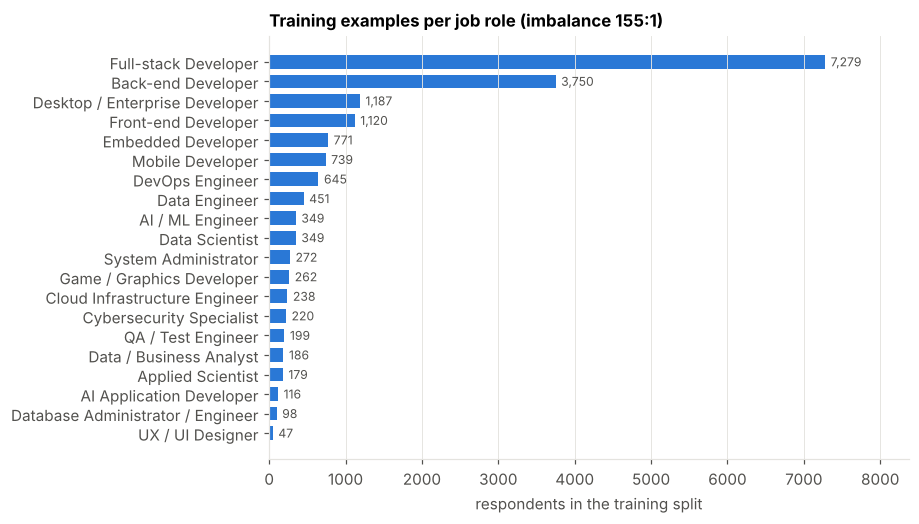

```python
counts = y_train.value_counts()
fig, ax = plt.subplots(figsize=(7.5, 5))
viz.barh(ax, [label(i) for i in counts.index], counts.to_numpy())
ax.set_title(f"Training examples per job role (imbalance {counts.max() / counts.min():.0f}:1)")
ax.set_xlabel("respondents in the training split")
plt.show()
```

## B2 · Algorithms and why each was chosen

The brief asks for at least four; seven are compared, chosen to cover **different inductive biases** (linear, max-margin, probabilistic, instance-based, bagged trees, boosted trees) plus a baseline. One product constraint applies to all of them: the app ranks roles by probability, so every model must give usable `predict_proba`. That is why Linear SVM is wrapped in `CalibratedClassifierCV`.

```python
spec = pd.DataFrame([{"model": n, "family": s["family"], "why it is here": s["why"]}
                     for n, s in M.candidates().items()])
with pd.option_context("display.max_colwidth", 140):
    display(spec)
```

|  | model | family | why it is here |
| --- | --- | --- | --- |
| 0 | Dummy (most frequent) | baseline | Floor for every metric. Its 39% accuracy next to a near-zero macro-F1 is the evidence that accuracy is the wrong headline metric here. |
| 1 | Complement Naive Bayes | probabilistic | Designed for imbalanced, sparse count-like data. Assumes features are conditionally independent, which technology lists clearly are not ... |
| 2 | k-Nearest Neighbours | instance-based | Directly tests the 'people with similar skill profiles do similar jobs' intuition behind the product. Cosine distance because the vector... |
| 3 | Logistic Regression | linear | Multinomial softmax on 479 mostly-binary features: the classic strong baseline for wide sparse data. Native well-behaved probabilities, ... |
| 4 | Linear SVM (calibrated) | linear (max-margin) | Max-margin boundaries often beat logistic loss on sparse high-dimensional data. LinearSVC has no predict_proba, so it is wrapped in Plat... |
| 5 | Random Forest | bagged trees | Captures skill *combinations* a linear model cannot (Terraform AND Python AND Kubernetes -> AI/ML engineer rather than three separate nu... |
| 6 | Hist Gradient Boosting | boosted trees | Strongest tree-based option: each round corrects the previous rounds' errors, which usually helps the rare roles. Expensive here because... |

## B3 · Validation strategy

- **Stratified 5-fold cross-validation on the training split only.** Stratified because the smallest class has 47 rows; 5 folds leaves about 9 of them per validation fold (10 folds would leave 4, too few to estimate a per-class F1).
- **The whole preprocessor sits inside the pipeline**, so each fold refits the vocabulary, rare-category pooling, imputation medians, scaler and variance filter on its own training part. Fitting preprocessing once before CV would leak validation information.
- **The 20% test split is not used for any comparison or tuning** (Part E is the only place).

```python
print(M.cv())
print("\nEvery candidate is: Pipeline([('prep', build_preprocessor()), ('clf', <model>)])")
```

```
StratifiedKFold(n_splits=5, random_state=42, shuffle=True)

Every candidate is: Pipeline([('prep', build_preprocessor()), ('clf', <model>)])
```

## B4 · Metrics, and why accuracy is not the headline

| Metric | Why |
| --- | --- |
| **macro-F1** (primary) | averages F1 over the 20 roles equally, so ignoring a rare role is punished as much as ignoring Full-stack |
| balanced accuracy | mean recall per role: does it find each role at all |
| **top-3 accuracy** | what the user sees: the app shows three roles |
| log loss | the app prints probabilities, so their quality matters |
| family macro-F1 / top-3 | the career-family recommendation, from the same probabilities |
| accuracy | shown only to prove it misleads (see the Dummy row) |

```python
stage6 = read_csv("stage6_model_comparison.csv")
cols = ["model", "f1_macro", "f1_macro_std", "balanced_accuracy", "accuracy", "top3_accuracy",
        "log_loss", "family_f1_macro", "family_top3_accuracy", "fit_seconds"]
stage6[cols].round(4)
```

|  | model | f1_macro | f1_macro_std | balanced_accuracy | accuracy | top3_accuracy | log_loss | family_f1_macro | family_top3_accuracy | fit_seconds |
| --- | --- | --- | --- | --- | --- | --- | --- | --- | --- | --- |
| 0 | Hist Gradient Boosting | 0.2724 | 0.0095 | 0.2477 | 0.5602 | 0.8289 | 1.4739 | 0.3926 | 0.8614 | 179.4674 |
| 1 | Logistic Regression | 0.2547 | 0.0031 | 0.3321 | 0.3657 | 0.7262 | 2.2691 | 0.3485 | 0.7783 | 91.7110 |
| 2 | Random Forest | 0.2537 | 0.0082 | 0.2404 | 0.5541 | 0.8301 | 1.6078 | 0.3750 | 0.8548 | 4.2860 |
| 3 | Linear SVM (calibrated) | 0.1911 | 0.0080 | 0.1776 | 0.5368 | 0.8092 | 1.5348 | 0.3274 | 0.8507 | 11.6381 |
| 4 | Complement Naive Bayes | 0.1786 | 0.0024 | 0.2030 | 0.4917 | 0.7210 | 2.3284 | 0.1583 | 0.6320 | 2.5034 |
| 5 | k-Nearest Neighbours | 0.1676 | 0.0038 | 0.1510 | 0.4997 | 0.7814 | 4.4130 | 0.2822 | 0.8192 | 1.4387 |
| 6 | Dummy (most frequent) | 0.0283 | 0.0000 | 0.0500 | 0.3944 | 0.4117 | 21.8289 | 0.0471 | 0.6614 | 1.8408 |

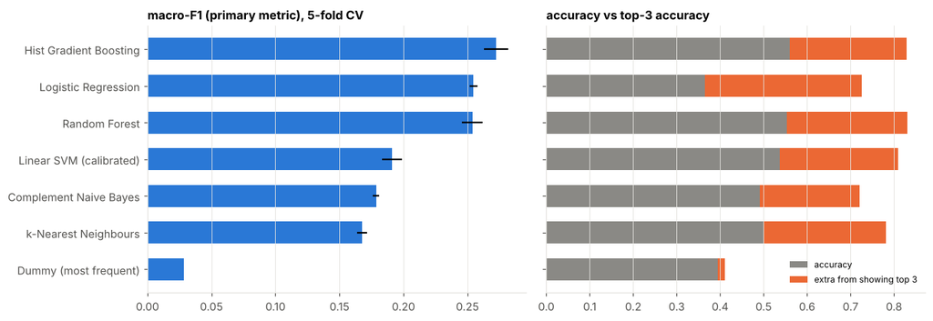

```
Dummy (always Full-stack): accuracy 0.394, macro-F1 0.028
→ a model that knows nothing gets ~39% accuracy. Accuracy alone would hide that.
```

```python
s6 = stage6.sort_values("f1_macro")
fig, axes = plt.subplots(1, 2, figsize=(12, 4.2), sharey=True)
axes[0].barh(s6["model"], s6["f1_macro"], xerr=s6["f1_macro_std"], color=viz.BLUE, height=0.6)
axes[0].set_title("macro-F1 (primary metric), 5-fold CV")
axes[1].barh(s6["model"], s6["accuracy"], color=viz.MUTED, height=0.6, label="accuracy")
axes[1].barh(s6["model"], s6["top3_accuracy"] - s6["accuracy"], left=s6["accuracy"],
             color=viz.ORANGE, height=0.6, label="extra from showing top 3")
axes[1].set_title("accuracy vs top-3 accuracy")
axes[1].legend(loc="lower right", fontsize=8)
for ax in axes:
    ax.grid(axis="y", visible=False)
plt.tight_layout()
plt.show()

d = stage6.set_index("model")
dummy = d.loc["Dummy (most frequent)"]
print(f"Dummy (always Full-stack): accuracy {dummy['accuracy']:.3f}, macro-F1 {dummy['f1_macro']:.3f}")
print("→ a model that knows nothing gets ~39% accuracy. Accuracy alone would hide that.")
```

## B6 · Where the errors are (out-of-fold, best Stage 6 model)

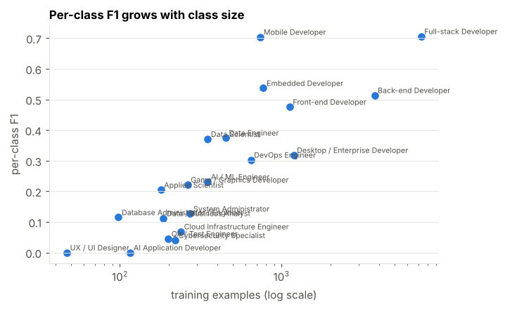

|  | actual | predicted_as | share_of_actual | same_family |
| --- | --- | --- | --- | --- |
| 0 | UX / UI Designer | Full-stack Developer | 0.596 | False |
| 1 | Front-end Developer | Full-stack Developer | 0.558 | False |
| 2 | AI Application Developer | Full-stack Developer | 0.500 | False |
| 3 | System Administrator | Full-stack Developer | 0.478 | False |
| 4 | Cybersecurity Specialist | Full-stack Developer | 0.418 | False |
| 5 | QA / Test Engineer | Full-stack Developer | 0.397 | False |
| 6 | Desktop / Enterprise Developer | Full-stack Developer | 0.389 | False |
| 7 | Cloud Infrastructure Engineer | Back-end Developer | 0.387 | False |

```python
per_class = read_csv("stage6_per_class_report.csv")
per_class["job_role"] = per_class["job_role"].map(label)
pc = per_class.sort_values("support")
fig, ax = plt.subplots(figsize=(6.5, 4))
ax.scatter(pc["support"], pc["f1-score"], color=viz.BLUE)
for _, r in pc.iterrows():
    ax.annotate(r["job_role"], (r["support"], r["f1-score"]), fontsize=7, color=viz.TEXT2,
                xytext=(3, 2), textcoords="offset points")
ax.set_xscale("log")
ax.set_xlabel("training examples (log scale)")
ax.set_ylabel("per-class F1")
ax.set_title("Per-class F1 grows with class size")
ax.grid(axis="both")
plt.show()

conf = pd.DataFrame(read_json("stage6_report.json")["top_confusions"])
conf["actual"] = conf["actual"].map(label)
conf["predicted_as"] = conf["predicted_as"].map(label)
conf.head(8)
```

**Finding:** almost all of the biggest confusions point **at Full-stack**, across family boundaries (UX/UI, front-end, AI-apps, sysadmin). Full-stack is a "sink" for anything the model is unsure about. So the main problem is **imbalance, not role overlap**, which is why Stage 7 starts with imbalance handling.

# Part C · Stage 7, optimisation

Four phases, each answering one question. All on the training split with the same folds.

## Phase A · Does imbalance handling help?

Tested on two algorithms so the answer is not specific to one. **SMOTE was rejected**: 403 of 479 features are 0/1 skill flags and an interpolated row would "0.4 know React". Oversampling sits *inside* the estimator so copies never cross a fold boundary.

```python
phase_a = read_csv("stage7_a_imbalance.csv")
phase_a[["model", "f1_macro", "f1_macro_std", "balanced_accuracy", "accuracy",
         "top3_accuracy", "fit_seconds"]].round(4)
```

|  | model | f1_macro | f1_macro_std | balanced_accuracy | accuracy | top3_accuracy | fit_seconds |
| --- | --- | --- | --- | --- | --- | --- | --- |
| 0 | Logistic Regression + no imbalance handling | 0.3003 | 0.0081 | 0.2865 | 0.5480 | 0.8297 | 106.2616 |
| 1 | Logistic Regression + oversampling to 10% | 0.2914 | 0.0041 | 0.3073 | 0.5123 | 0.8089 | 16.8593 |
| 2 | Random Forest + class_weight | 0.2548 | 0.0070 | 0.2414 | 0.5535 | 0.8294 | 3.2074 |
| 3 | Logistic Regression + class_weight | 0.2535 | 0.0017 | 0.3288 | 0.3650 | 0.7269 | 73.4602 |
| 4 | Random Forest + oversampling to 10% | 0.2153 | 0.0042 | 0.1920 | 0.5410 | 0.8263 | 3.3256 |
| 5 | Random Forest + no imbalance handling | 0.1869 | 0.0063 | 0.1738 | 0.5411 | 0.8201 | 2.6819 |

**The surprise of the project.** Stage 6 used `class_weight="balanced"` everywhere as an obvious precaution. Phase A shows it **hurts Logistic Regression** (0.300 → 0.254 when added; accuracy collapses to 0.365) but **helps Random Forest** (0.187 → 0.255). Weighting forces the softmax to inflate rare-role probabilities everywhere: recall on rare roles goes up, precision falls further, and macro-F1 drops. Trees partition the space, so weighting just makes the rare classes visible to the split criterion. **Lesson: imbalance handling is a property of the algorithm-data pair, not a universal good.**

## Phase B · Do the Stage 4 feature decisions hold up?

```python
phase_b = read_csv("stage7_b_features.csv")
ref = phase_b.loc[phase_b["model"] == "core (reference)", "f1_macro"].iloc[0]
sd = phase_b.loc[phase_b["model"] == "core (reference)", "f1_macro_std"].iloc[0]
phase_b.assign(delta_vs_core=phase_b["f1_macro"] - ref)[
    ["model", "f1_macro", "delta_vs_core", "top3_accuracy", "note"]].sort_values(
    "delta_vs_core", ascending=False).round(4)
```

|  | model | f1_macro | delta_vs_core | top3_accuracy | note |
| --- | --- | --- | --- | --- | --- |
| 0 | core+context (506 features) | 0.2605 | 0.0065 | 0.7413 | phase B: adds OrgSize/Industry/RemoteWork/ICorPM |
| 1 | rare pooling 1% | 0.2547 | 0.0006 | 0.7299 | phase B: fewer technology columns |
| 2 | core (reference) | 0.2541 | 0.0000 | 0.7301 | phase B: 479 features, the Stage 4 default |
| 3 | rare pooling 0.25% | 0.2528 | -0.0012 | 0.7296 | phase B: more technology columns |
| 4 | want lists removed | 0.2451 | -0.0089 | 0.7008 | phase B: does 'what they want to learn' add anything ove... |
| 5 | SelectKBest chi2 k=300 | 0.2353 | -0.0188 | 0.7102 | phase B: selection fitted inside every fold |
| 6 | SelectKBest chi2 k=200 | 0.2315 | -0.0225 | 0.6868 | phase B: selection fitted inside every fold |
| 7 | SelectKBest chi2 k=all | 0.2290 | -0.0251 | 0.7353 | phase B: selection fitted inside every fold |
| 8 | SelectKBest chi2 k=100 | 0.2277 | -0.0264 | 0.6489 | phase B: selection fitted inside every fold |

- **"Want to learn" columns earn their place:** removing them costs 0.009 macro-F1 and 0.029 top-3.
- **Rare-pooling threshold 0.5% is on a flat optimum** (±0.001, below fold noise).
- **SelectKBest (chi²) does not help.** The `k=all` row does no selection and still drops 0.025, because that branch scales the 0/1 skill flags; this is evidence for the Stage 4 decision to leave binary columns unscaled. Selection sits inside the pipeline (no leak).
- **core+context scores highest but is rejected:** students have no employer, so OrgSize, Industry and RemoteWork would be blank in the app (train/serve mismatch). The +0.006 is also within noise.

## Phase C · Hyper-parameter search

**Randomised search, not grid search**, optimising macro-F1 with the same stratified folds. A 5-parameter grid with 4 values each is 1,024 fits per model; random search finds a near-best setting in tens of fits because only two or three parameters usually matter. Boosting was searched on 3 folds for cost, then re-scored on 5 so all numbers are comparable.

```python
best_params = read_json("stage7_best_params.json")
for m, p in best_params.items():
    print(f"{m:<26}" + ", ".join(f"{k.split('__')[-1]}={round(v, 5) if isinstance(v, float) else v}"
                                   for k, v in p.items()))
```

```
Logistic Regression       C=0.21752, class_weight=None
Linear SVM (calibrated)   C=0.00355, class_weight=balanced
Random Forest             n_estimators=300, min_samples_leaf=4, max_features=0.1, max_depth=40, class_weight=balanced
Hist Gradient Boosting    min_samples_leaf=50, max_leaf_nodes=15, max_iter=200, learning_rate=0.2, l2_regularization=1.0
```

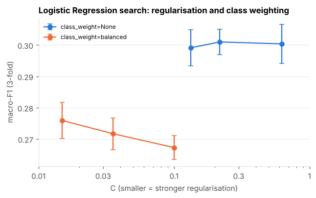

```python
search_lr = read_csv("stage7_c_search_logistic.csv").sort_values("param_clf__C")
fig, ax = plt.subplots(figsize=(6.5, 3.6))
for cw, g in search_lr.groupby(search_lr["param_clf__class_weight"].fillna("None")):
    ax.errorbar(g["param_clf__C"], g["mean_test_score"], yerr=g["std_test_score"],
                marker="o", capsize=3, label=f"class_weight={cw}")
ax.set_xscale("log")
ax.xaxis.set_minor_formatter(plt.NullFormatter())
ax.set_xticks([0.01, 0.03, 0.1, 0.3, 1], ["0.01", "0.03", "0.1", "0.3", "1"])
ax.set_xlabel("C (smaller = stronger regularisation)")
ax.set_ylabel("macro-F1 (3-fold)")
ax.set_title("Logistic Regression search: regularisation and class weighting")
ax.legend(fontsize=8)
ax.grid(axis="both")
plt.show()
```

The search was free to pick `class_weight="balanced"` and chose `None`, confirming Phase A by a different route. Both linear models moved to **stronger regularisation** than the default (LR C=1 → 0.218, SVM → 0.0036): with 479 features and 47 examples in the smallest class, the defaults were overfitting.

## Phase D · Tuned vs baseline

|  | model | baseline_f1_macro | tuned_f1_macro | gain | tuned_f1_macro_std | baseline_top3 | tuned_top3 | tuned_balanced_accuracy | tuned_log_loss | tuned_family_f1_macro | tuned_family_top3 | fit_seconds |
| --- | --- | --- | --- | --- | --- | --- | --- | --- | --- | --- | --- | --- |
| 0 | Logistic Regression | 0.2547 | 0.3030 | 0.0483 | 0.0082 | 0.7262 | 0.8387 | 0.2826 | 1.4146 | 0.4294 | 0.8733 | 3.3470 |
| 1 | Hist Gradient Boosting | 0.2724 | 0.2860 | 0.0135 | 0.0096 | 0.8289 | 0.8309 | 0.2605 | 1.4226 | 0.4030 | 0.8659 | 12.9254 |
| 2 | Random Forest | 0.2537 | 0.2820 | 0.0283 | 0.0081 | 0.8301 | 0.8131 | 0.2936 | 1.7325 | 0.3585 | 0.8211 | 4.2030 |
| 3 | Linear SVM (calibrated) | 0.1911 | 0.2536 | 0.0625 | 0.0090 | 0.8092 | 0.8401 | 0.2300 | 1.3998 | 0.3842 | 0.8749 | 4.2883 |

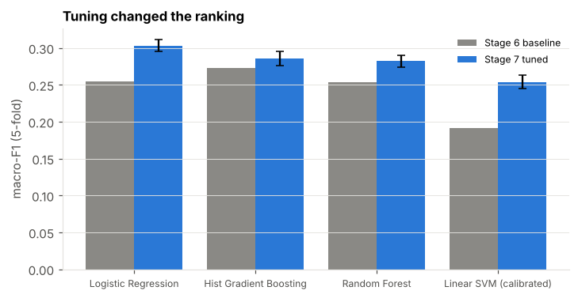

```python
phase_d = read_csv("stage7_d_tuned_vs_baseline.csv")
display(phase_d.round(4))

x = np.arange(len(phase_d))
fig, ax = plt.subplots(figsize=(7.5, 3.6))
ax.bar(x - 0.2, phase_d["baseline_f1_macro"], 0.4, color=viz.MUTED, label="Stage 6 baseline")
ax.bar(x + 0.2, phase_d["tuned_f1_macro"], 0.4, color=viz.BLUE, label="Stage 7 tuned",
       yerr=phase_d["tuned_f1_macro_std"], capsize=3)
ax.set_xticks(x, phase_d["model"], fontsize=8)
ax.set_ylabel("macro-F1 (5-fold)")
ax.set_title("Tuning changed the ranking")
ax.grid(axis="y")
ax.grid(axis="x", visible=False)
ax.legend(fontsize=8)
plt.show()
```

# Part D · Final model selection

The rule was fixed **before** reading the tuned results, so it could not be bent:

> Highest 5-fold macro-F1. Models within one standard deviation of the best are treated as tied, and the cheapest to fit wins.

The tie-break exists because Stage 6 showed gaps the size of fold noise.

```python
decision = read_json("stage7_final_selection.json")
best = phase_d.sort_values("tuned_f1_macro", ascending=False).iloc[0]
runner = phase_d.sort_values("tuned_f1_macro", ascending=False).iloc[1]
print("FINAL MODEL:", decision["final_model"], best_params[decision["final_model"]])
print(f"\nBest macro-F1 {best['tuned_f1_macro']:.4f} ± {best['tuned_f1_macro_std']:.4f}")
print(f"Runner-up     {runner['model']} {runner['tuned_f1_macro']:.4f}  "
      f"(gap {best['tuned_f1_macro'] - runner['tuned_f1_macro']:.4f} ≈ "
      f"{(best['tuned_f1_macro'] - runner['tuned_f1_macro']) / best['tuned_f1_macro_std']:.1f} SD)")
print("Tied within 1 SD:", decision["tied_within_1sd"], "→ the tie-break was not needed")
```

```
FINAL MODEL: Logistic Regression {'clf__C': 0.21751953118777648, 'clf__class_weight': None}

Best macro-F1 0.3030 ± 0.0082
Runner-up     Hist Gradient Boosting 0.2860  (gap 0.0171 ≈ 2.1 SD)
Tied within 1 SD: ['Logistic Regression'] → the tie-break was not needed
```

| Criterion | Winner | Note |
| --- | --- | --- |
| macro-F1 (primary) | **Logistic Regression 0.303** | only model within 1 SD of the best |
| family macro-F1 | **Logistic Regression 0.429** | the career-family recommendation |
| top-3 accuracy | Linear SVM 0.840 | LR 0.839, a 0.001 difference (noise) |
| log loss | Linear SVM 1.400 | LR 1.415, close; both well calibrated |
| fit time | **Logistic Regression 3.3 s** | 4× faster than boosting; 108 KB model file |
| explainability | **Logistic Regression** | one coefficient per skill per role (Part F) |

It wins the primary metric outright, and the secondary reasons (speed, size, explainability for the non-technical presentation in Stage 12) all point the same way.

# Part E · The one held-out test evaluation

`scripts/finalise_model.py` refit the chosen configuration on all 18,457 training rows and scored it once on the 4,615 test respondents. Below, the saved `model.joblib` is loaded and re-scored live; it must reproduce the stored numbers exactly (no decision depends on this rerun, so it does not turn the test set into a validation set).

```python
model = joblib.load(C.ARTIFACTS_DIR / "model.joblib")
X_test, y_test = M.load_test()
proba = model.predict_proba(X_test)
live = M.score_all(y_test, proba, model.classes_)
stored = read_json("stage7_test_results.json")

table = pd.DataFrame({
    "cross-validated (train)": pd.Series(stored["cv_scores"]),
    "test (stored)": pd.Series(stored["test_scores"]),
    "test (recomputed now)": pd.Series(live),
}).loc[["f1_macro", "top3_accuracy", "accuracy", "balanced_accuracy", "log_loss",
        "family_f1_macro", "family_top3_accuracy"]]
display(table.round(4).astype(object).where(table.notna(), "not stored"))
print(f"CV → test macro-F1 gap: {stored['cv_to_test_gap_f1_macro']:+.4f}  (small: validation was honest)")
print(f"Recomputed matches stored: {np.allclose(table['test (stored)'], table['test (recomputed now)'], atol=1e-4)}")
```

|  | cross-validated (train) | test (stored) | test (recomputed now) |
| --- | --- | --- | --- |
| f1_macro | 0.303 | 0.2845 | 0.2845 |
| top3_accuracy | 0.8387 | 0.8392 | 0.8392 |
| accuracy | not stored | 0.5493 | 0.5493 |
| balanced_accuracy | 0.2826 | 0.2657 | 0.2657 |
| log_loss | 1.4146 | 1.4146 | 1.4146 |
| family_f1_macro | 0.4294 | 0.4149 | 0.4149 |
| family_top3_accuracy | 0.8733 | 0.8778 | 0.8778 |

```
CV → test macro-F1 gap: -0.0185  (small: validation was honest)
Recomputed matches stored: True
```

**How to say it to a non-technical person:** for about **84 of every 100** new users, the role that actually fits them is in the three the app shows, and for about **88 of 100** their career family is in the top three. A single guess would be right about 55% of the time, which is why the app never shows only one answer.

```python
test_pc = read_csv("stage7_test_per_class.csv")
test_pc["job_role"] = test_pc["job_role"].map(label)
test_pc.sort_values("f1-score", ascending=False)[["job_role", "family", "precision", "recall",
                                                  "f1-score", "support"]].round(3)
```

|  | job_role | family | precision | recall | f1-score | support |
| --- | --- | --- | --- | --- | --- | --- |
| 0 | Mobile Developer | Mobile | 0.695 | 0.703 | 0.699 | 185.0 |
| 1 | Full-stack Developer | Full-stack | 0.618 | 0.788 | 0.693 | 1820.0 |
| 2 | Embedded Developer | Embedded/Systems | 0.519 | 0.570 | 0.543 | 193.0 |
| 3 | Back-end Developer | Backend | 0.518 | 0.517 | 0.517 | 937.0 |
| 4 | Front-end Developer | Frontend | 0.581 | 0.436 | 0.498 | 280.0 |
| 5 | Data Engineer | Data Eng | 0.448 | 0.345 | 0.390 | 113.0 |
| 6 | DevOps Engineer | DevOps/Cloud | 0.426 | 0.304 | 0.355 | 161.0 |
| 7 | Data Scientist | Data Sci/ML | 0.382 | 0.299 | 0.335 | 87.0 |
| 8 | AI / ML Engineer | Data Sci/ML | 0.343 | 0.276 | 0.306 | 87.0 |
| 9 | Desktop / Enterprise Developer | Desktop/Enterprise | 0.344 | 0.246 | 0.287 | 297.0 |
| 10 | Applied Scientist | Data Sci/ML | 0.282 | 0.244 | 0.262 | 45.0 |
| 11 | Game / Graphics Developer | Game/Graphics | 0.333 | 0.197 | 0.248 | 66.0 |
| 12 | Data / Business Analyst | Data Sci/ML | 0.194 | 0.128 | 0.154 | 47.0 |
| 13 | QA / Test Engineer | QA/Test | 0.333 | 0.060 | 0.102 | 50.0 |
| 14 | System Administrator | DevOps/Cloud | 0.147 | 0.074 | 0.098 | 68.0 |
| 15 | Cloud Infrastructure Engineer | DevOps/Cloud | 0.150 | 0.051 | 0.076 | 59.0 |
| 16 | Database Administrator / Engineer | Data Eng | 0.333 | 0.042 | 0.074 | 24.0 |
| 17 | Cybersecurity Specialist | Security | 0.100 | 0.036 | 0.053 | 55.0 |
| 18 | AI Application Developer | Data Sci/ML | 0.000 | 0.000 | 0.000 | 29.0 |
| 19 | UX / UI Designer | Frontend | 0.000 | 0.000 | 0.000 | 12.0 |

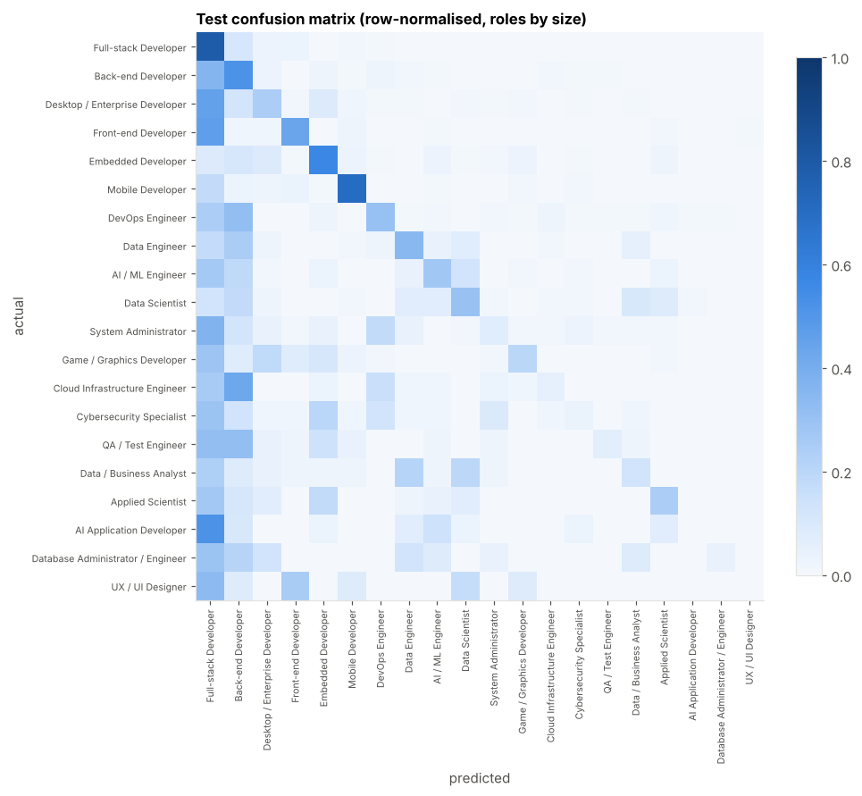

```python
from sklearn.metrics import confusion_matrix

classes = list(model.classes_)
order = [c for c in y_train.value_counts().index]
cm = confusion_matrix(y_test, np.asarray(classes)[proba.argmax(1)], labels=order, normalize="true")
fig, ax = plt.subplots(figsize=(8.5, 7.5))
im = ax.imshow(cm, cmap=viz.seq_cmap(), vmin=0, vmax=1)
ax.set_xticks(range(len(order)), [label(c) for c in order], rotation=90, fontsize=7)
ax.set_yticks(range(len(order)), [label(c) for c in order], fontsize=7)
ax.set_xlabel("predicted")
ax.set_ylabel("actual")
ax.grid(False)
ax.set_title("Test confusion matrix (row-normalised, roles by size)")
fig.colorbar(im, ax=ax, fraction=0.04)
plt.show()
```

# Part F · The model in use

## F1 · Live prediction for a sample user

This goes through the **same path the web backend will use**: a JSON profile → `profile_to_frame()` → the saved pipeline. Stage 7 already checked 300 real rows through this path with a maximum probability difference of 0.0.

```python
profile = {
    "country": "Sri Lanka", "years_code": 4, "work_exp": 1,
    "ed_level": "Some college/university study without earning a degree",
    "tech": {
        "Language": {"have": ["Python", "SQL", "R"], "want": ["Scala"]},
        "Database": {"have": ["PostgreSQL", "Databricks SQL"], "want": ["Snowflake"]},
        "Platform": {"have": ["Docker", "Microsoft Azure"], "want": ["Kubernetes"]},
        "DevEnvs": {"have": ["Visual Studio Code", "Jupyter Notebook/JupyterLab"], "want": []},
        "SOTags": {"have": ["Polars", "Microsoft Fabric"], "want": []},
    },
    "ai": {"AISelect": "Yes, I use AI tools daily", "AIAgents": "No, but I plan to"},
    "learn_code_ai": "Yes, I learned how to use AI-enabled tools required for my job or to benefit my career",
}
p = model.predict_proba(profile_to_frame(profile))[0]
roles = pd.DataFrame(targets.top_k(p, model.classes_, k=3))[["label", "family", "probability"]]
fams = pd.DataFrame(targets.top_k_families(p, model.classes_, k=3))
display(Markdown("**Top 3 job roles**"), roles.round(3),
        Markdown("**Top 3 career families**"), fams.round(3))
```

**Top 3 job roles**

|  | label | family | probability |
| --- | --- | --- | --- |
| 0 | Data Engineer | Data Eng | 0.393 |
| 1 | Data Scientist | Data Sci/ML | 0.257 |
| 2 | AI / ML Engineer | Data Sci/ML | 0.241 |

**Top 3 career families**

|  | family | probability |
| --- | --- | --- |
| 0 | Data Sci/ML | 0.543 |
| 1 | Data Eng | 0.393 |
| 2 | Backend | 0.025 |

Try changing the skills above (for example add `React`, `TypeScript` under a `Webframe` block, or `Kubernetes`/`Terraform` under `Platform` as "have") and re-run the cell: the ranking moves the way a person would expect.

## F2 · Why it predicts what it predicts

Logistic Regression has one coefficient per feature per role, so "which skills push towards a role" can be read directly. Most features are 0/1 skill flags and the numeric ones are standardised, so coefficients can be compared within a role.

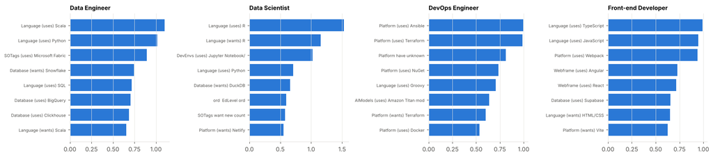

```python
names = model.named_steps["prep"].get_feature_names_out()
coef = pd.DataFrame(model.named_steps["clf"].coef_, index=model.classes_, columns=names)


def pretty(f):
    return (f.replace("tech__", "").replace("_have__", " (uses) ").replace("_want__", " (wants) ")
            .replace("_", " "))


show = [r for r in ["Data engineer", "Data scientist", "DevOps engineer or professional",
                    "Developer, front-end"] if r in coef.index]
fig, axes = plt.subplots(1, len(show), figsize=(4.2 * len(show), 3.8))
for ax, role in zip(np.atleast_1d(axes), show):
    top = coef.loc[role].sort_values(ascending=False).head(8)[::-1]
    ax.barh([pretty(f)[:32] for f in top.index], top.to_numpy(), color=viz.BLUE)
    ax.set_title(label(role), fontsize=10)
    ax.tick_params(axis="y", labelsize=7)
    ax.grid(axis="y", visible=False)
plt.tight_layout()
plt.show()
```

# Quick answers for the viva

| Likely question | Short answer |
| --- | --- |
| Why macro-F1 and not accuracy? | 155:1 imbalance. A model that always says Full-stack gets ~39% accuracy and ~0.03 macro-F1. |
| Why stratified 5-fold? | Keeps every role in every fold; 5 folds still leaves ~9 UX/UI rows per fold. |
| How did you prevent leakage? | Preprocessing, resampling and feature selection all inside the pipeline, refit per fold; test split only opened once at the end. |
| Why not SMOTE? | Features are 0/1 skills; synthetic rows would be impossible profiles. |
| Why random search? | Grid = 1,024 fits per model; random search finds near-best in tens of fits. |
| Biggest single improvement? | Removing `class_weight="balanced"` from Logistic Regression: +0.047 macro-F1. |
| Why not the Stage 6 winner (boosting)? | After tuning LR beat it by ~2 SD, and is 4× faster and explainable. |
| Why is top-1 accuracy only 55%? | Roles genuinely overlap (DevOps vs Cloud 0.99 similarity); top-3 is 84%, which is what users see. |
| Did the model generalise? | CV macro-F1 0.303 vs test 0.285, a small gap; top-3 identical (0.839). |
| Why not use OrgSize/Industry when they helped? | Students cannot answer them; the gain was within noise anyway. |

More detail and evidence: `reports/modelling_decisions.md`, `reports/SkillPath_Stage6-8_Report.pdf`.